# Portafolio de trabajos Estadistica A0501

Mateo Nicolay Rogeron Maila

2024-07-07

## **1. Temario de clases**

## **2. Resolución de Ejercicios propuestos**

### 2.1. INTERVALOS DE CONFIANZA

**9.4.** Las estaturas de una muestra aleatoria de 50 estudiantes universitarios tienen una media de 174.5 centímetros y una desviación estándar de 6.9 centímetros.

1. Construya un intervalo de confianza del 98% para la estatura media de los estudiantes universitarios.
2. ¿Qué podemos afirmar con una confianza del 98% acerca del posible tamaño de nuestro error, si estimamos que la estatura media de todos los estudiantes universitarios es de 174.5 centímetros?

**9.6.** ¿Qué tan grande debe ser la muestra en el ejercicio 9.2 si deseamos tener un 96% de confi anza en que nuestra media muestral estará dentro de 10 horas a partir de la media verdadera?

**9.13.** En un estudio para determinar la dureza de Rockwell en la cabeza de alfileres para costura se toma una muestra aleatoria de 12. Se toman mediciones de la dureza de Rockwell para cada una de las 12 cabezas y se obtiene un valor promedio de 48.50, con una desviación estándar muestral de 1.5. Suponga que las mediciones se distribuyen de forma normal y con base en esto construya un intervalo de confi anza de 90% para la dureza media de Rockwell.

**9.16.** Considere el ejercicio 9.10 y calcule el intervalo de predicción del 95% para el siguiente número observado de palabras por minuto tecleadas por una graduada de la escuela de secretarias.

**9.35** Una muestra aleatoria de tamaño $n_1 = 25$, tomada de una población normal con una desviación estándar $\sigma_1 = 5$, tiene una media $x_{1}^{-} = 80$. Una segunda muestra aleatoria de tamaño $n_2 = 36$, que se toma de una población normal diferente con una desviación estándar $\sigma_2 = 3$, tiene una media $x_{2}^{-} = 75$. Calcule un intervalo de confianza del 94% para $(\mu_1 - \mu_2)$.

### 2.2. CONTRASTE DE HIPÓTESIS

## **3. Consultas**

## Ejemplo de Resumen del tema: Promedio muestral

### Promedio muestral:

El promedio aritmético o muestral, es la medida de tendencia central más comúnmente utilizada, la cual se define de la siguiente manera:

> Sea $x_1, x_2,\ldots, x_n$ un conjunto de $n$ datos muestrales, entonces, el promedio muestral $\bar{X}$ se obtiene de la siguiente manera:
> $$\bar{X} = \frac{x_1 + x_2 + \ldots
> x_n}{n} = \frac{\sum_{i=1}^{n}x_i }{n}$$

#### Ejemplo:

Los tiempos de conexión (en horas) de un cliente a un servidor informático de una empresa durante la última semana, son los siguientes:

| dias | Lunes | Martes | Miércoles | Jueves | Viernes |
| --- | --- | --- | --- | --- | --- |
| horas | 5.6 | 3.7 | 6.2 | 5.6 | 7.2 |

El promedio muestral del tiempo de conexión (en horas) de este cliente se calcularía de la siguiente manera:

$$\bar{X} = \frac{5.6 + 3.7 + 6.2 + 5.6 +
7.2}{5} = \frac{28.3}{5} = 5.66$$

Este promedio se puede calcular paso a paso usando **R** de la siguiente manera:

```r
promedio <- (5.6 + 3.7 + 6.2 + 5.6 + 7.2)/5
promedio
```

```
## [1] 5.66
```

También es posible calcularlo, utilizando la función **mean**:

```r
horas <- c(5.6, 3.7, 6.2, 5.6, 7.2)
promedio <- mean(horas)
promedio
```

```
## [1] 5.66
```

La interpretación geométrica del promedio muestral es similar concepto del centro de gravedad del conjunto de datos: si distribuimos los puntos observados a lo largo del eje horizontal, entonces el promedio muestral se ubica en el punto en el cual se equilibra el “peso” del conjunto de puntos.

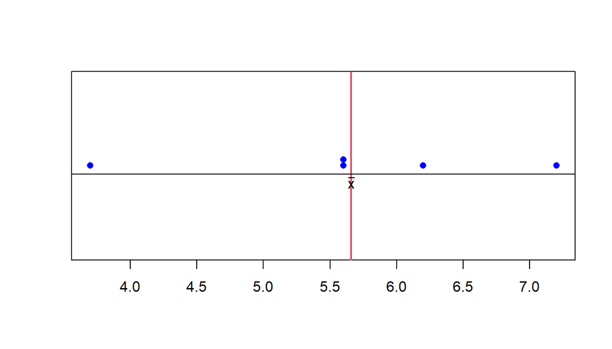